[figure not shown]

# This notebook is made to analyze Walmart, a big retail store. We'll look at data to find important patterns and trends that can help understand how Walmart is doing in its business.

# First Step: Understanding the Data

## In the first step, we will look at the data distribution to understand it better. This will help us see what the data looks like and what information it contains.

```python
import pandas as pd
import matplotlib.pyplot as plt
import seaborn as sns
import numpy as np

df = pd.read_csv('walmart-sales-dataset-of-45stores.csv')
df[['Weekly_Sales','Holiday_Flag','Temperature','Fuel_Price','Unemployment']].describe()
```

|  | Weekly_Sales | Holiday_Flag | Fuel_Price | Unemployment |
| --- | --- | --- | --- | --- |
| count | 6.435000e+03 | 6435.000000 | 6435.000000 | 6435.000000 |
| mean | 1.046965e+06 | 0.069930 | 3.358607 | 7.999151 |
| std | 5.643666e+05 | 0.255049 | 0.459020 | 1.875885 |
| min | 2.099862e+05 | 0.000000 | 2.472000 | 3.879000 |
| 25% | 5.533501e+05 | 0.000000 | 2.933000 | 6.891000 |
| 50% | 9.607460e+05 | 0.000000 | 3.445000 | 7.874000 |
| 75% | 1.420159e+06 | 0.000000 | 3.735000 | 8.622000 |
| max | 3.818686e+06 | 1.000000 | 4.468000 | 14.313000 |

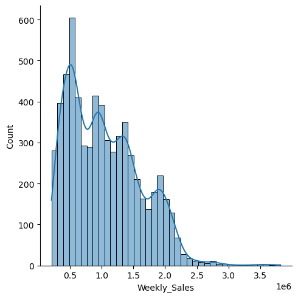

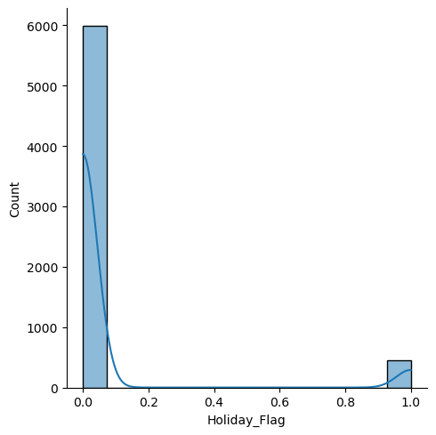

[figure not shown]

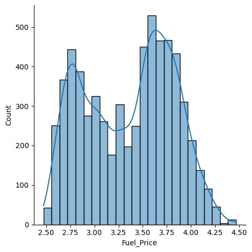

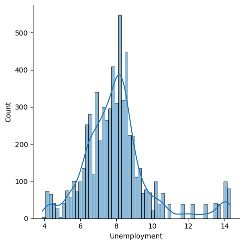

```python
selecte_col=df[['Weekly_Sales','Holiday_Flag','Temperature','Fuel_Price','Unemployment']]
for col in selecte_col:
    sns.displot(df[col], kde=True)

plt.tight_layout()
plt.show()
```

```python
print(df.head(10))
df.info()
```

```
   Store        Date  Weekly_Sales  Holiday_Flag Temperature  Fuel_Price  \
0      1    5/2/2010    1643690.90             0       42.31       2.572
1      1   12/2/2010    1641957.44             1       38.51       2.548
2      1  19/02/2010    1611968.17             0       39.93       2.514
3      1  26/02/2010    1409727.59             0       46.63       2.561
4      1    5/3/2010    1554806.68             0        46.5       2.625
5      1   12/3/2010    1439541.59             0       57.79       2.667
6      1  19/03/2010    1472515.79             0       54.58       2.720
7      1  26/03/2010    1404429.92             0       51.45       2.732
8      1    2/4/2010    1594968.28             0       62.27       2.719
9      1    9/4/2010    1545418.53             0       65.86       2.770

        CPI  Unemployment  Unnamed: 8
0  211.0964         8.106         NaN
1  211.2422         8.106         NaN
```

[output cut: 24 more lines]

# Data Cleaning

```python
df['Date'] = pd.to_datetime(df['Date'], errors='coerce')
df.isnull().sum()
```

```
Store              0
Date            3870
Weekly_Sales       0
Holiday_Flag       0
Temperature        0
Fuel_Price         0
CPI                0
Unemployment       0
Unnamed: 8      6435
dtype: int64
```

# Checking for Duplicates

```python
df.duplicated().sum()
```

```
0
```

# Outlier Detection with IQR

### This means there are no duplicate rows. Next, we'll check for outliers using the Interquartile Range (IQR) method.

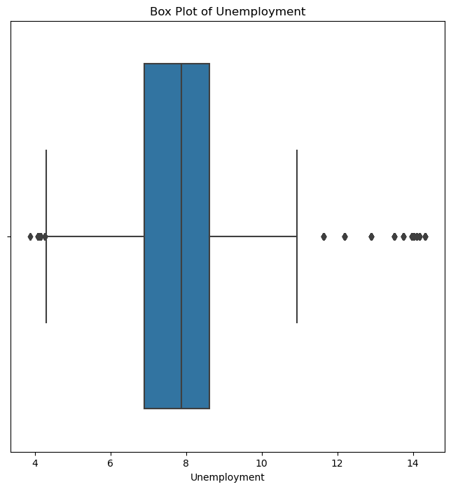

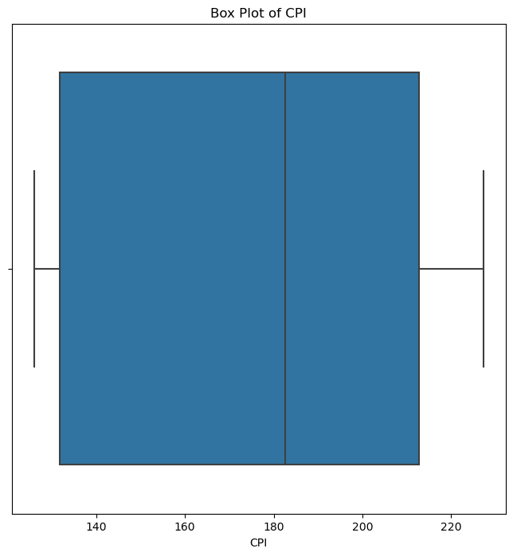

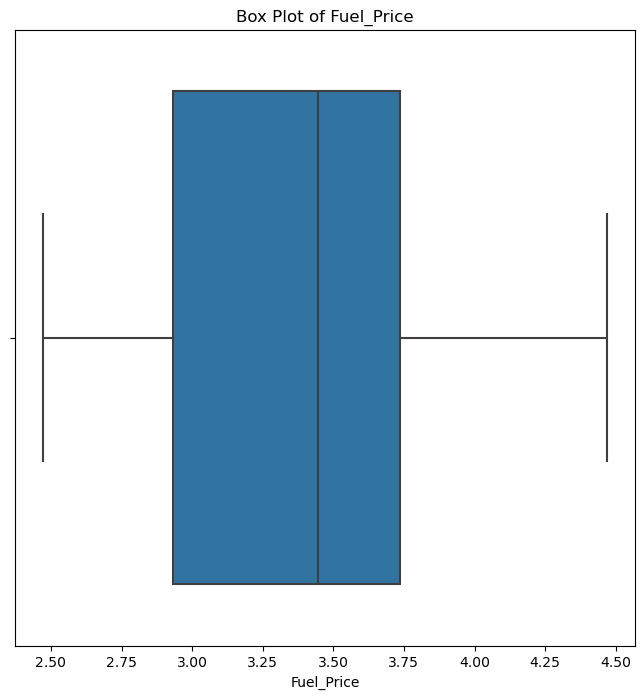

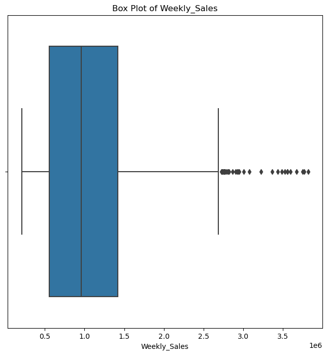

[output not shown]

```python
#i will use iqr for this task
selected_columns = ['Unemployment', 'CPI', 'Fuel_Price', 'Weekly_Sales', 'Temperature']

for col in selected_columns:
    plt.figure(figsize=(8, 8))
    sns.boxplot(x=df[col])
    plt.title(f'Box Plot of {col}')
    plt.show()
```

## i use IQR for outlines

```python
selected_columns = ['Unemployment', 'Weekly_Sales', 'Temperature']
for col in selected_columns:
    q1=df[col].quantile(0.25)
    q3=df[col].quantile(0.75)
    iqr=q3-q1
    width=1.5
    lower=q1-(width*iqr)
    higher=q3+(width*iqr)
    df[col]=np.where(df[col]>higher,higher,np.where(df[col]<lower,lower,df[col]))
```

```python
selected_columns = ['Unemployment', 'Weekly_Sales', 'Temperature']

for col in selected_columns:
    plt.figure(figsize=(8, 8))
    sns.boxplot(x=df[col])
    plt.title(f'Box Plot of {col}')
    plt.show()
```

[output not shown]

# Adding New Columns

### Now that the data is cleaned, the next step is to add new columns. These will help in the analysis and in answering key questions.

```python
"""
bins = [0, 3, 6, 9, 12]

labels = ['Semester 1', 'Semester 2', 'Semester 3', 'Semester 4']

df['Semester'] = pd.cut(df['Date'].dt.month, bins=bins, labels=labels)
"""


semester_map = {
    1: 'Winter', 2: 'Winter', 3: 'Spring',
    4: 'Spring', 5: 'Spring', 6: 'Summer',
    7: 'Summer', 8: 'Summer', 9: 'Fall',
    10: 'Fall', 11: 'Fall', 12: 'Winter'
}
df['Semester'] = df['Date'].dt.month.map(semester_map)

print(df)
```

```
      Store       Date  Weekly_Sales  Holiday_Flag Temperature  Fuel_Price  \
0         1 2010-05-02    1643690.90             0       42.31       2.572
1         1 2010-12-02    1641957.44             1       38.51       2.548
2         1        NaT    1611968.17             0       39.93       2.514
3         1        NaT    1409727.59             0       46.63       2.561
4         1 2010-05-03    1554806.68             0        46.5       2.625
...     ...        ...           ...           ...         ...         ...
6430     45        NaT     713173.95             0       64.88       3.997
6431     45 2012-05-10     733455.07             0       64.89       3.985
6432     45 2012-12-10     734464.36             0       54.47       4.000
6433     45        NaT     718125.53             0       56.47       3.969
6434     45        NaT     760281.43             0       58.85       3.882

           CPI  Unemployment  Unnamed: 8 Semester
0     211.0964         8.106         NaN   Spring
1     211.2422         8.106         NaN   Winter
2     211.2891         8.106         NaN      NaN
3     211.3196         8.106         NaN      NaN
4     211.3501         8.106         NaN   Spring
...        ...           ...         ...      ...
6430  192.0136         8.684         NaN      NaN
6431  192.1704         8.667         NaN   Spring
6432  192.3273         8.667         NaN   Winter
6433  192.3309         8.667         NaN      NaN
6434  192.3089         8.667         NaN      NaN

[6435 rows x 10 columns]
```

# Two Approaches: Visualizing Data or Using Code

### There are two ways to proceed: by visualizing the data or by analyzing it with code. Both methods will help in understanding the data and finding insights.

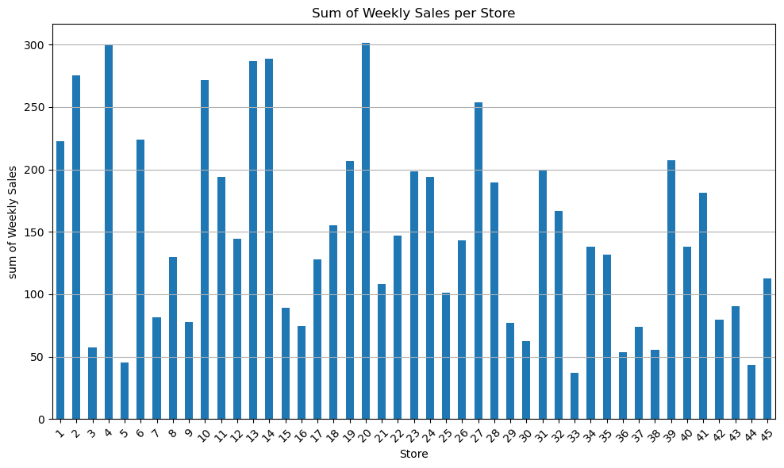

```python
sales_sum = df.groupby('Store')['Weekly_Sales'].sum() / 1000000


plt.figure(figsize=(10, 6))
sales_sum.plot(kind='bar')
plt.ylabel('sum of Weekly Sales')
plt.title('Sum of Weekly Sales per Store')
plt.xticks(rotation=45)
plt.grid(axis='y')
plt.tight_layout()
plt.show()
```

```python
print(sales_sum.head(45))

max_store = sales_sum.idxmax()
max_value = sales_sum[max_store]

print("Store", max_store, "has the maximum sales of", max_value, "M")
```

```
Store
1     222.402809
2     275.382441
3      57.586735
4     299.543953
5      45.475689
6     223.756131
7      81.598275
8     129.951181
9      77.789219
10    271.617714
11    193.962787
12    144.287230
13    286.517704
14    288.999911
```

[output cut: 33 more lines]

# b) Which store has maximum standard deviation i.e., the sales vary a lot

```python
sales_std = df.groupby('Store')['Weekly_Sales'].std()
print(sales_std.head(45))

max_storestd = sales_std.idxmax()
max_valuestd = sales_std[max_storestd]

print("Store", max_storestd, "standard deviation of", max_valuestd.round(2))
```

```
Store
1     155980.767761
2     237683.694682
3      46319.631557
4     266201.442297
5      37737.965745
6     212525.855862
7     112585.469220
8     106280.829881
9      69028.666585
10    302262.062504
11    165833.887863
12    139166.871880
13    265506.995776
14    317569.949476
```

[output cut: 33 more lines]

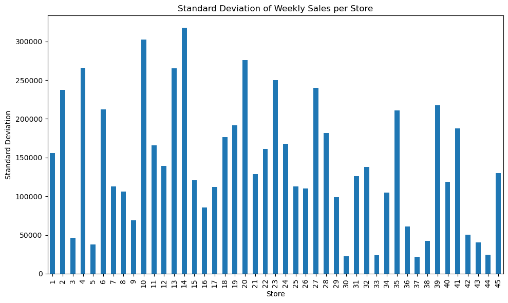

```python
plt.figure(figsize=(10, 6))
sales_std.plot(kind='bar')
plt.ylabel('Standard Deviation')
plt.title('Standard Deviation of Weekly Sales per Store')
plt.tight_layout()
plt.show()
```

# c) Some holidays have a negative impact on sales. Find out holidays that have higher sales than the mean sales in the non-holiday season for all stores together.

```python
holiday = df.groupby('Holiday_Flag')['Weekly_Sales'].mean()
print("Mean of the non holiday sales : ",holiday[0].round(2))

high_sales = df[df['Holiday_Flag'] ==1][df[df['Holiday_Flag'] ==1]['Weekly_Sales'] >holiday[0]]

num = len(high_sales)

print("Number of rows in the DataFrame:", num)
print(high_sales['Date'].unique())
```

```
Mean of the non holiday sales :  1041256.38
Number of rows in the DataFrame: 220
<DatetimeArray>
['2010-12-02 00:00:00', '2010-10-09 00:00:00',                 'NaT',
 '2011-11-02 00:00:00', '2011-09-09 00:00:00', '2012-10-02 00:00:00',
 '2012-07-09 00:00:00']
Length: 7, dtype: datetime64[ns]
```

# d) Provide a monthly and semester view of sales in units and give insights.

```
Month 1:  $181,559,036
Month 2:  $240,969,530
Month 3:  $239,446,787
Month 4:  $239,102,000
Month 5:  $237,986,299
Month 6:  $244,777,717
Month 7:  $186,820,779
Month 8:  $188,500,877
Month 9:  $245,069,649
Month 10:  $246,383,762
Month 11:  $235,190,163
Month 12:  $232,764,958
Semester Fall: $726,643,574
Semester Spring: $716,535,086
Semester Summer: $620,099,373
Semester Winter: $655,293,525
```

```
array([<Axes: title={'center': 'Weekly_Sales'}, xlabel='Semester'>],
      dtype=object)
```

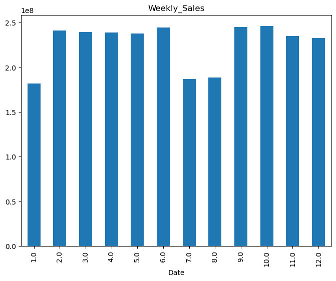

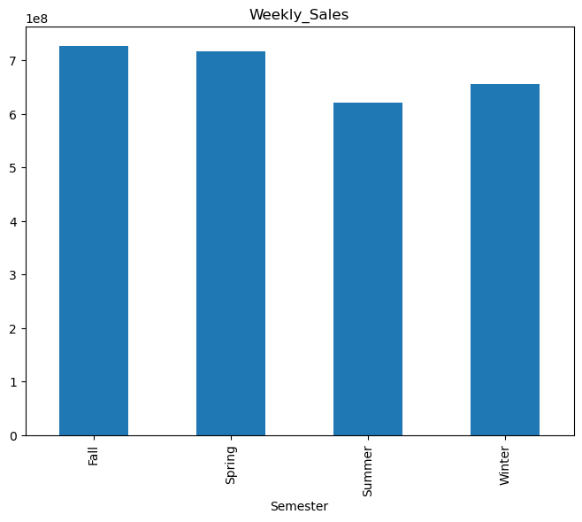

```python
# monthly_sales = (df.groupby([df['Date'].dt.year, df['Date'].dt.month])['Weekly_Sales'].sum()).round(2)
monthly_sales = (df.groupby(df['Date'].dt.month)['Weekly_Sales'].sum()).round(2)
semesterly_sales = (df.groupby('Semester')['Weekly_Sales'].sum()).round(2)

#for (year, month), sales in monthly_sales.items():
#    print(f"{year}-{month:02}: ${sales:,.0f}")

for month_index, sales in enumerate(monthly_sales, start=1):
    print(f"Month {month_index}:  ${sales:,.0f}")

for semester, sales in semesterly_sales.items():
    print(f"Semester {semester}: ${sales:,.0f}")

plt.figure(figsize=(8, 6))
monthly_sales.plot(kind='bar', subplots=True)

plt.figure(figsize=(8, 6))
semesterly_sales.plot(kind='bar', subplots=True)
```

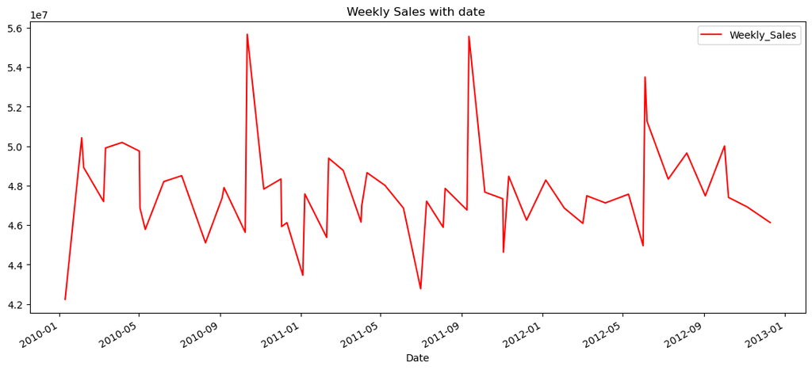

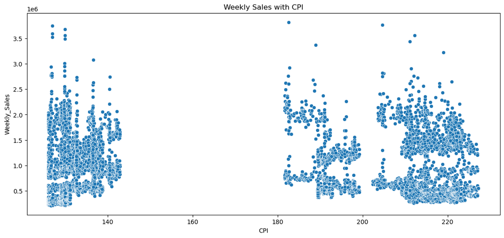

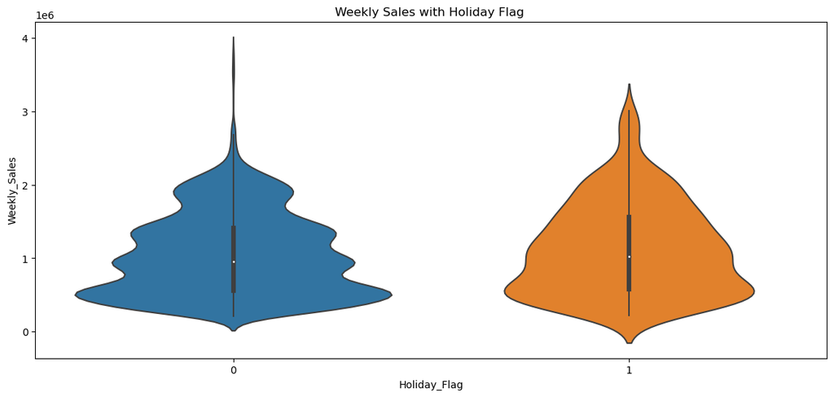

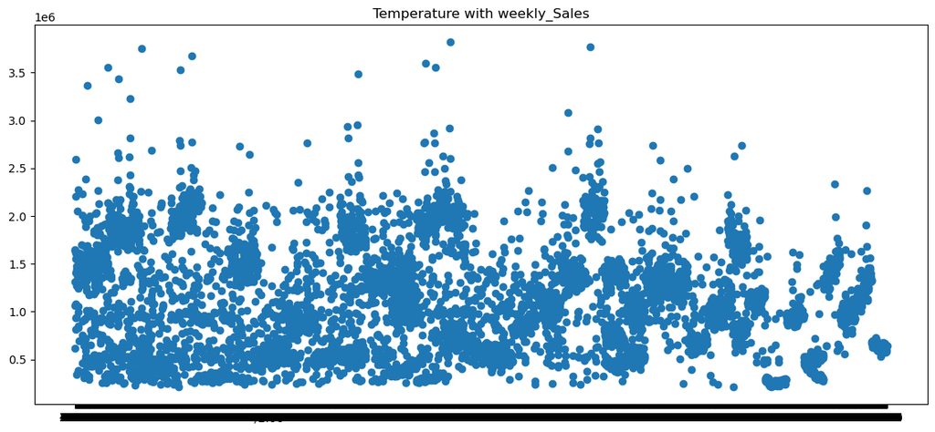

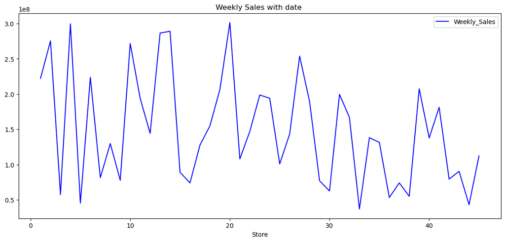

```python
sales = df.groupby("Date")[["Weekly_Sales"]].sum()
sales.plot(color='red', figsize=(14, 6))
plt.title('Weekly Sales with date ')

plt.figure(figsize=(14, 6))
sns.scatterplot(data=df, x='CPI', y='Weekly_Sales')
plt.title('Weekly Sales with CPI')

plt.figure(figsize=(14, 6))
sns.violinplot(data=df, x='Holiday_Flag', y='Weekly_Sales')
plt.title('Weekly Sales with Holiday Flag ')

plt.figure(figsize = (14,6))
plt.scatter( df['Temperature'] ,df['Weekly_Sales'] )
plt.title("Temperature with weekly_Sales")

sales_store = df.groupby("Store")[["Weekly_Sales"]].sum()
sales_store.plot(color='blue', figsize=(14, 6))
plt.title('Weekly Sales with date ')
```

```
array([<Axes: >, <Axes: >, <Axes: >, <Axes: >], dtype=object)
```

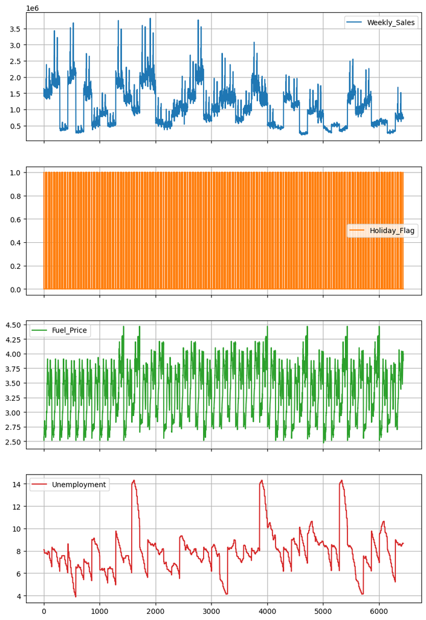

```python
selecte_col.plot(subplots=True, grid=True, figsize=(10,15))
```

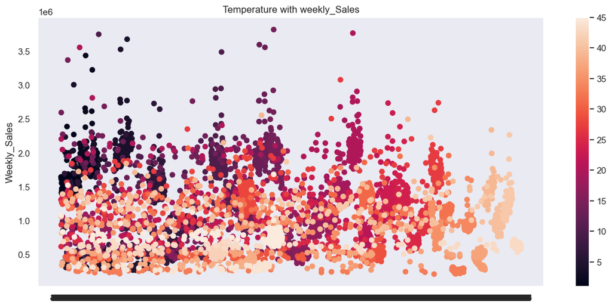

```python
plt.figure(figsize = (14,6))
sns.set(style='dark')
plt.scatter( df['Temperature'] ,df['Weekly_Sales'] , c = df['Store'])
plt.colorbar()
plt.ylabel("Weekly_Sales")
plt.title("Temperature with weekly_Sales")
```

## Correlation between Columns

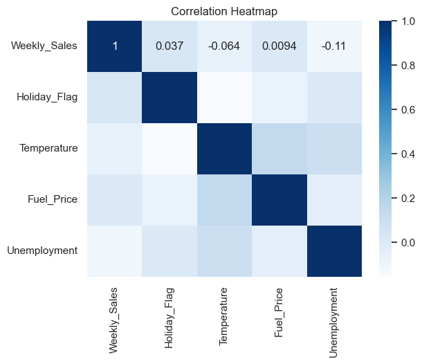

```python
selecte_col = selecte_col.apply(pd.to_numeric, errors='coerce')  # Convert non-numeric to NaN
selecte_col = selecte_col.dropna()  # Drop rows with NaN values

# Compute correlation matrix
correlation_matrix = selecte_col.corr()

# Plot heatmap
sns.heatmap(correlation_matrix, annot=True, cmap="Blues")
plt.title('Correlation Heatmap')
plt.show()
```